# 第八周：第六章 重点解析 1

[figure not shown]

[figure not shown]

School of Social Development

多源数据分析与实践 · Week 8

[interactive chart not shown]

# 第六章 重点解析 1

Hugging Face AI 开源工具生态

主讲人：刘贇喆 副教授 | 华东师范大学 社会发展学院

[interactive chart not shown]

目录

[interactive chart not shown]

**目录** CONTENTS

1.0 网络导论

01

SECTION**01 / 06**

## 1.0网络导论

Introduction to Networks

1.0 网络导论

Social Media Nodes Shortest Path Flow Communities Edges Food Web Power Grid Bridges Citation Centrality Followers Mobility Density Trade Routes Connectivity Edge Weight Modularity

[interactive chart not shown]

1.0 网络导论

## 节点、边与图

Nodes, Edges, and Graphs

**节点node**

表示研究中的对象

**边edge**

记录对象之间选定的关系

**图graph**

由节点集合与边集合组成

[figure not shown]

**A**

[B, C, D]

**B**

[A]

**C**

[A, D, E, F]

**D**

[A, C]

**E**

[C]

**F**

[C]

G = (V, E)

**节点集合 V**

{A, B, C, D, E, F}

**边集合 E**

{{A, B}, {A, C}, {A, D}, {C, D}, {C, E}, {C, F}}

**V** 表示顶点集合，顶点（vertex）也称节点（node）。

1.0 网络导论

## 哪些对象可以相连？

What Can Be Connected?

这四种关系都可以用节点和边表示。

### 人和人

两位作者共同署名。

### 物和物

一篇论文引用另一篇论文。

### 人和物

读者借阅了一本书。

### 人和空间

一位居民到访社区广场。

人和组织、机构之间……不同的联系，都可以用节点和连线来表达。

1.0 网络导论

## 哥尼斯堡七桥问题

The Seven Bridges of Königsberg

怎样走才能每座桥恰好经过一次？

[figure not shown]

Handmann 绘 · 1753

### 莱昂哈德·欧拉

Leonhard Euler · 1707–1783

瑞士数学家。他在《无穷分析引论》中写出了联系复指数与三角函数的欧拉公式 *e*<sup>*ix*</sup> = cos *x* + *i* sin *x*。

18 世纪，他从桥连接了哪些陆地入手，研究哥尼斯堡七桥问题。这项研究成为图论的早期经典。

七桥示意图

[figure not shown]

陆地变节点，桥变边。两座桥保留为两条平行边。

**展开七桥推理**

每个中途节点的进、出成对，奇数度节点只能出现在起点或终点。

A、B、C、D 的度数为 5、3、3、3，四处都是奇数度，因此无解。

无向图中，有边的节点相互可达，且恰有 0 或 2 个奇数度节点。

此时存在**欧拉通路**，可恰好走过每条边一次。

1.0 网络导论

## 方向与权重

Direction and Weight

### 方向从谁指向谁？

无向关系

微信好友

有向关系

微博、小红书的账号关注

### 权重边上记录什么数？

无权表示

两位作者是否合著过

加权表示

两位作者合著的篇数

### 有向加权网络

以单日跨区出行为例。箭头指向到达区，数字和线宽表示行程数。

1.0 网络导论

## 如何定义一条边？

Defining Edges

建网前先明确节点是什么、何时记一条边，再确定方向、权重和观察时段。

### 引用网络

节点是论文，边是引用。

### 合著网络

节点是作者，边是共同署名。

### 道路网络

节点是路口，边是可通行路段。

### OD 流动网络

节点是区域，边是区际出行。

1.0 网络导论

## 网络结构指标

Network Measures

- **规模** 数节点和边
- **密度** 实际边数 ÷ 最大可能边数

**规模**

6 个节点，7 条边

**密度**

7 ÷ 15 ≈ **0.467**

看节点能否沿边互相到达。

全图有 1 个连通分量

[figure not shown]

- **度中心性** 数直接邻居
- **中介中心性** 看最短路径经过谁

C、D 各有 3 个邻居

组内连边占比减去随机期望。

**分为 ABC 和 DEF**

**Q ≈ 0.357**

**合为一个社区**

Q = 0

2.0 专题研究 1

02

SECTION**02 / 06**

## 2.0专题研究 1

Topic Study 1

2.0 专题研究 1

## GitHub

Code Hosting and Collaboration

GitHub 是软件开发与开源协作的平台。

在这里可以创建仓库、关注开发者、参与开源项目。

**README**

读项目介绍和使用方法

**Commits**

查看每次修改和提交者

**Star**

收藏感兴趣的仓库

**Fork**

复制一份仓库，方便独立修改

**Issues**

反馈问题或提出建议

**Pull requests**

提议合并代码修改，供他人审阅

示例仓库 [`huggingface/transformers`](https://github.com/huggingface/transformers)

[video not shown]

普通人如何用好 GitHub？李大可爱玩 · 6:27 · 默认 1.2× [原视频 ↗](https://www.bilibili.com/video/BV1m4GhzEER3/)

2.0 专题研究 1

## Hugging Face（抱抱脸）

Models, Datasets, and Spaces

Hugging Face 提供机器学习工具。

它的 Hub 用于查找、分享和试用 AI 资源。

**Models**

找文本分类、图像生成等模型

**Datasets**

找训练和评估模型用的数据

**Spaces**

在浏览器里试用或发布 AI 应用

### 开放权重模型

- Qwen3-8B
- DeepSeek-R1
- gpt-oss-20b

以上模型均开放权重，可在满足硬件要求的电脑上本地部署。

[video not shown]

Hugging Face 入门秋芝2046 · 5:49 · 默认 1.2× [原视频 ↗](https://www.bilibili.com/video/BV1Mr4MewEY5/)

2.0 专题研究 1

## 开源项目与开发者网络

Open-Source Developer Networks

Hugging Face 哪些开发者参与过同一开源项目？

**参与范围**

有多少账号参与了不止一个所选仓库？

**直接连接**

哪个账号直接连接的开发者最多？

**中介位置**

连接数排名靠后，中介排名也会靠后吗？

**社区划分**

Louvain 把这些账号分成了几个社区？

### 合著与专利合作

- 共同署名论文，连接合著作者。
- 共同申请专利，连接高校或科研机构，也可按机构所在地连接城市。

**二模网络** 圆点是开发者账号，方框是代码仓库。

**单模投影** 边上的数字是共同仓库数，下方列出仓库名。

2.0 专题研究 1

## 网络构建案例

Building Networks from Data

### 哪些记录可以 连成网络？

合著与共同申请专利留下合作记录。网页共现可用来估计村际联系。

1. **01**

   **节点用什么单位？**

   先确定分析单位，可以是作者、机构、城市或村庄。
2. **02**

   **什么证据能连边？**

   按共同署名、共同申请专利或网页共现记录配对。
3. **03**

   **边的数值怎么解释？**

   区分共同记录数与有向转移量，再比较节点位置与分组。

### 论文案例

[DOI ↗](https://doi.org/10.1038/s44284-025-00209-x)

2.0 专题研究 1

## GONets 数据集

GitHub Organization Networks

### 数据规模

v1 采集于 2025 年 6–12 月，2026 年 2 月发布。

**GitHub 组织**

超过 23 万

**代码仓库**

437 万

**独立账号**

252 万

**账号与仓库的贡献关联**

近 3,000 万

Hugging Face 仓库关联账号数（中位数 5）

### 所选 Hugging Face 仓库

20 个

- `transformers`
- `diffusers`
- `candle`
- `open-r1`

**作者** Hridoy Sankar Dutta · Biswadeep Khan · Parth Mitesh Shah · Amit A. Nanavati

3.0 样本与建网

03

SECTION**03 / 06**

## 3.0样本与建网

Sampling and Graph Construction

3.0 样本与建网

## 从 CSV 到 tidygraph 网络

From CSV to tidygraph

课堂代码节选

### 建图字段与参数

`developer_id` 唯一标识账号。

`from`、`to` 对应连边两端的账号 ID。

`directed = FALSE` 表示连边没有方向。

### CSV 节选

节点表 `developers.csv`

| `developer_id` | `github_name` | `repository_count`仓库数 |
| --- | --- | --- |
| `dev_0001` | `julien-c` | 5 |
| `dev_0002` | `thomwolf` | 8 |
| `dev_0004` | `Pierrci` | 2 |
| `dev_0035` | `alexander-soare` | 1 |

连边表 `edges.csv`

| `from` | `to` | `shared_repositories`共同仓库数 |
| --- | --- | --- |
| `dev_0001` | `dev_0002` | 3 |
| `dev_0001` | `dev_0004` | 2 |
| `dev_0002` | `dev_0004` | 1 |
| `dev_0002` | `dev_0035` | 1 |

3.0 样本与建网

## 样本筛选与开发者网络

Sample Selection and Developer Network

### 筛选仓库

1. **301**→**20**个仓库

   从组织图按工具用途选取

### 清理记录

2. **600**→**594**条参与记录

   排除 6 条机器人记录，再按账号与仓库去重

单仓库参与跨仓库参与

### 账号数

**单仓库参与**

330 个**80.9%**

**跨仓库参与**

78 个**19.1%**

### 参与记录数

**单仓库参与**

330 条**55.6%**

**跨仓库参与**

264 条**44.4%**

两个账号共同参与同一所选仓库，就连一条无向边。

### 开发者共同参与网络

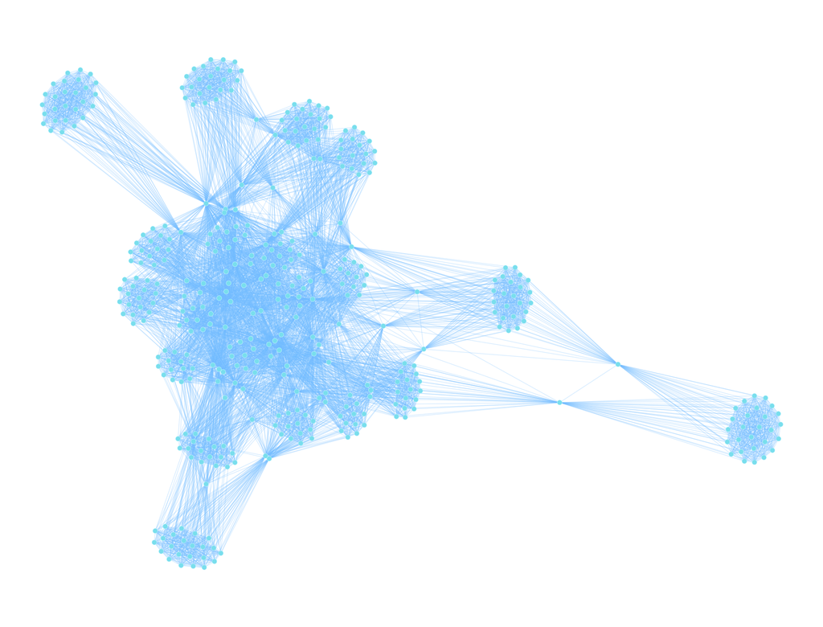

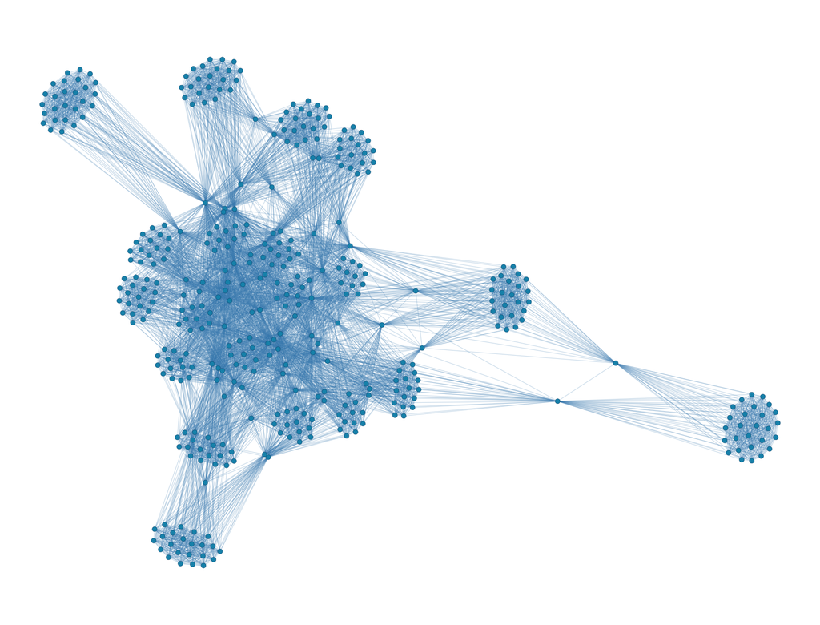

**408** 个账号 · **7,856** 条无向边

4.0 中心性比较

04

SECTION**04 / 06**

## 4.0中心性比较

Comparing Centrality Measures

4.0 中心性比较

## 绘制三种中心性网络图

Visualizing Centrality

布局

色盘

### 中心性计算参数

`weights = NA`，按直接连接数计算。

`normalized = TRUE`，对中介中心性标准化。

`directed = FALSE`，按无向图计算。

### 参与类型

- 单仓库参与
- 跨仓库参与

### 中心性分级

点大小按当前指标分级 · 指向节点或连边查看

4.0 中心性比较

## 开发者的中心性排名

Developer Centrality Rankings

### Joshua Lochner

[@xenova ↗](https://github.com/xenova)

创建 Transformers.js，让模型在浏览器中运行。

**度**

并列 46

**中介**

3

**PageRank**

43

任一指标进入前 5 · 7 个账号

5.0 社区与项目

05

SECTION**05 / 06**

## 5.0社区与项目

Communities and Projects

5.0 社区与项目

## 用 Louvain 划分社区

Louvain Community Detection

原图 408 个节点 · 7,856 条边

### 模块度优化

逐点比较移入相邻社区的收益，只接受正增益。

合并为超节点后继续扫描，聚合时 Q 不变。

组内连边比例减去给定度数下的随机期望。

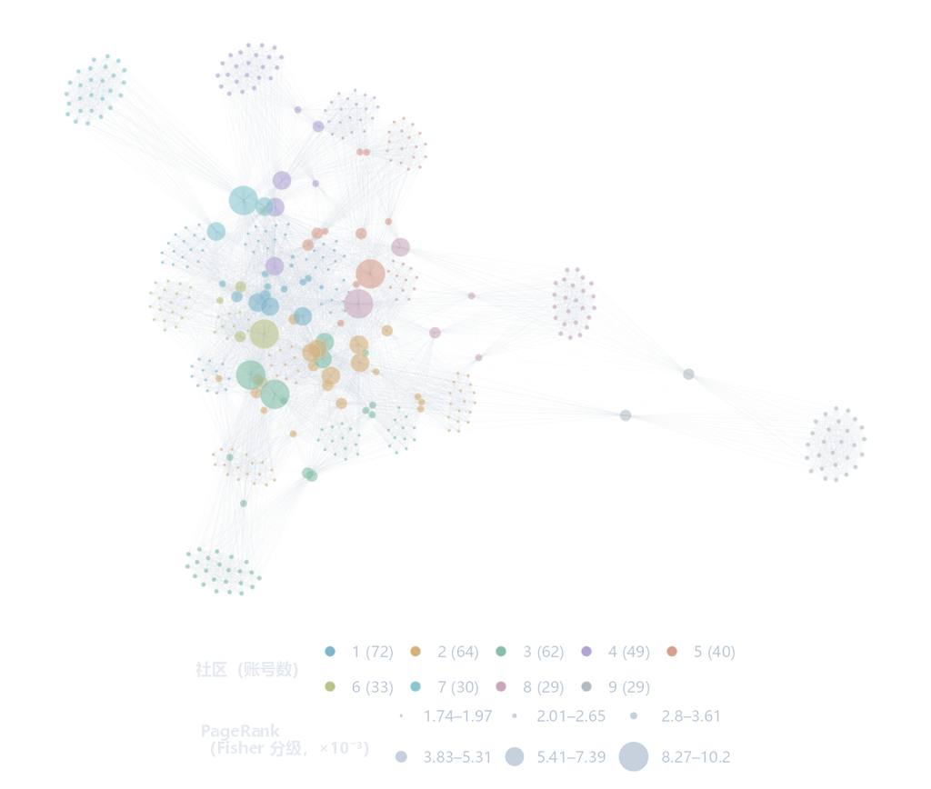

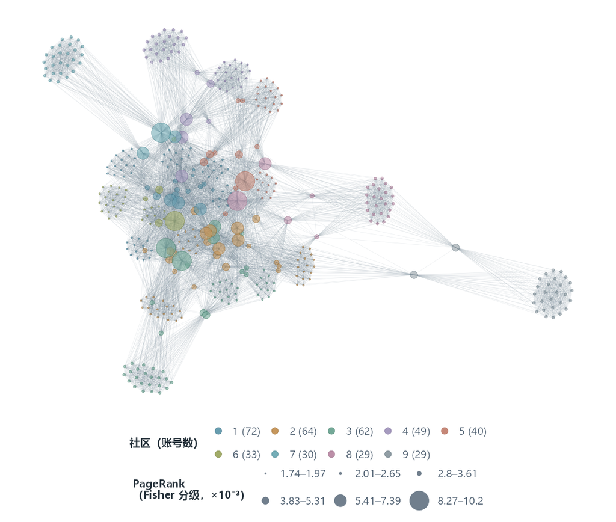

**社区数**

9

**模块度 Q**

0.5547

教材的最终社区划分

5.0 社区与项目

## 九个开发者社区

Nine Developer Communities

社区按参与覆盖率较高的仓库用途暂名。

### 社区暂名

账号数

### 全网总览

6.0 回顾与反思

06

SECTION**06 / 06**

## 6.0回顾与反思

Review and Reflection

6.0 回顾与反思

## 从仓库到社区

From Repositories to Communities

研究回顾 方法反思

1. **Hugging Face** GitHub 组织GONets v1 参与记录
2. **20 个仓库** 每仓库 30 条原始记录清洗后共 594 条
3. **共同参与建网** 同仓库账号两两连边408 个账号 · 7,856 条边
4. **计算中心性** 度 · 中介 · PageRank
5. **Louvain 划分** 9 个社区模块度 Q ≈ 0.555
6. **解读社区** 按仓库构成暂名比较中心性与代表账号

### 共同参与网络

### 中心性排名对照

| 账号 | 度 | 中介 | PageRank |
| --- | --- | --- | --- |
| `thomwolf` | 1 | 1 | 1 |
| `lewtun` | 2 | 4 | 2 |
| `Wauplin` | 3 | 2 | 3 |
| `Narsil` | 5并列 | 6 | 5 |
| `xenova` | 46并列 | 3 | 43 |

### 各社区账号数

### 连边代表什么？

同仓库账号两两连边。判断直接协作还需代码审查或 Issue 互动记录。

### 样本覆盖多大？

**301****20**个仓库

仓库按用途选取。每个仓库的源记录最多收录 30 个账号。

### 高排名说明什么？

度中介PageRank

中心性描述网络位置。评估投入需核对提交、审查等独立记录。

### 坐标和分组怎么来？

**FR**坐标

**Louvain**分组

图上距离取决于布局。改变 Louvain 分辨率可检查分组稳定性。

如果改用代码审查互动连边，哪些社区还会出现？

多源数据分析与实践 · Week 8

[interactive chart not shown]

# Thanks

第八周：第六章 重点解析 1

主讲人：刘贇喆 副教授 | 华东师范大学 社会发展学院

01

08

滚轮 / 方向键 / 空格切换

00:00:00